# Mini-Project 01

# Set-up

In the set-up for this mini-project, the first thing is to load the **tidyverse package** using the **library** function and then have R read the excel data and assign it to a variable. A table can then be outputted, as shown below, to show the tibble of the data.

```r
library(tidyverse)
credit <- read_csv("https://raw.githubusercontent.com/aalhamadani/datasets/refs/heads/main/Credit.csv", col_types = cols())
credit
```

```
## # A tibble: 400 × 11
##    Income Limit Rating Cards   Age Education Gender Student Married Ethnicity
##     <dbl> <dbl>  <dbl> <dbl> <dbl>     <dbl> <chr>  <chr>   <chr>   <chr>
##  1   14.9  3606    283     2    34        11 Male   No      Yes     Caucasian
##  2  106.   6645    483     3    82        15 Female Yes     Yes     Asian
##  3  105.   7075    514     4    71        11 Male   No      No      Asian
##  4  149.   9504    681     3    36        11 Female No      No      Asian
##  5   55.9  4897    357     2    68        16 Male   No      Yes     Caucasian
##  6   80.2  8047    569     4    77        10 Male   No      No      Caucasian
##  7   21.0  3388    259     2    37        12 Female No      No      African Ame…
##  8   71.4  7114    512     2    87         9 Male   No      No      Asian
##  9   15.1  3300    266     5    66        13 Female No      No      Caucasian
## 10   71.1  6819    491     3    41        19 Female Yes     Yes     African Ame…
## # ℹ 390 more rows
## # ℹ 1 more variable: Balance <dbl>
```

# Analysis and Results

For this analysis, graphs such as **scatter plots** and **bar charts** were focused on. Using the *“Chart Suggestions-A Though Starter”* diagram as a reference, these were the most optimized choices for the variable comparisons and relationships that were chosen to be analyzed.

### Credit Limit vs Annual Income

First the relationship between credit card limit and income was analyzed using a scatter plot, as can be seen below. The trend that can be seen is mostly linear. This shows that the higher the income someone makes the higher credit card limit they receive. This graph also indicates a bit of congestion towards the bottom left of the graph, showing a trend that the vast majority of the people in this data tended to fall within a lower income and therefore lower limit.

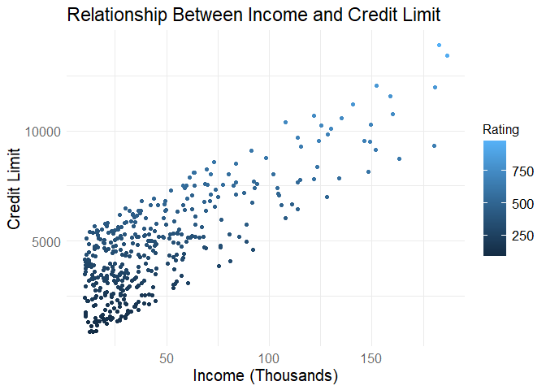

```r
# Plot a scatter plot of Limit vs. Income, coloring by rating
ggplot(credit, aes(x = Income, y = Limit, color = Rating)) +
  geom_point() +
  # Create title and axis labels for the graph
  labs(title = "Relationship Between Income and Credit Limit", x = "Income (Thousands)", y = "Credit Limit") +
  # Alter the theme of the graph
  theme_minimal() +
  theme(plot.title = element_text(size = 17),
        axis.title.x = element_text(size = 15),
        axis.title.y = element_text(size = 15),
        axis.text.x = element_text(size = 12, color = "gray40"),
        axis.text.y = element_text(size = 12, color = "gray40"),
        legend.key.size = unit(0.75, 'cm'),
        legend.text = element_text(size = 13),
        legend.title = element_text(size = 12))
```

### Amount of People vs. Number of Credit Cards

Next the amount of people in correspondence to the numbers of credit cards they have was analyzed using a bar chart. This visual helps show the average number of credit cards a person has normally falls between 2-4, with very few people having 5 or more.

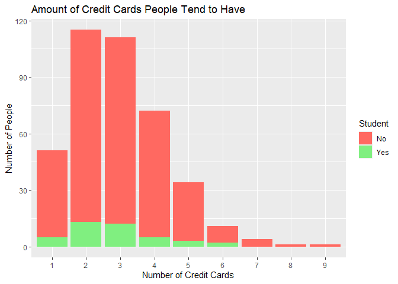

```r
# Create a bar chart of number of credit cards
ggplot(credit, aes(x = factor(Cards), fill = Student)) +
  geom_bar() +
  # Create title and axis labels for the graph
  labs(x = "Number of Credit Cards", y = "Number of People", title = "Amount of Credit Cards People Tend to Have") +
  scale_fill_manual(values = c("Yes" = "#80EF80", "No" = "#FF6961"))
```

```r
  # Remove the legend as its redundant
  #theme(legend.position = "none")
```

### Credit Score vs Balance in Regards to Credit Limit

Another analysis using a scatter plot was done on the relationship between credit score and current balance. The scatter plot was then colored in respect to the limit on the credit card to help show a larger trend. The graph depicts a somewhat linear trend between credit score and the balance on the card. The graph also shows a somewhat linear trend in the coloring as well. This showcases that people with a high balance as well as a higher limit on their card tend to have a higher credit score in return.

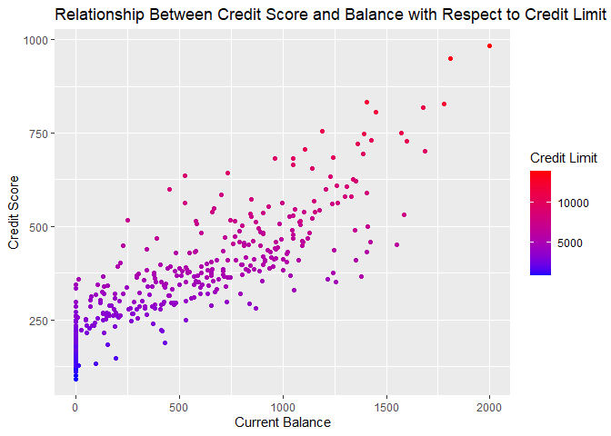

```r
# Create a scatter plot of credit score vs balance, coloring by credit limit
ggplot(credit, aes(x = Balance, y = Rating, color = Limit)) +
  geom_point() +
  # Change the color gradient to desired color choices
  scale_color_gradient(low = "blue", high = "red") +
  # Create title and axis labels for the graph
  labs(x = "Current Balance", y = "Credit Score", color = "Credit Limit", title = "Relationship Between Credit Score and Balance with Respect to Credit Limit")
```

### Credit Score vs Balance Corresponding to Gender and Ethnicity

Lastly two sets of scatter plots, shown below, compare the relationship of rating vs balance against the variable gender and then against the variable ethnicity. Here it can be seen that there is very little to no trend in either category as they all show very a similar trend and look to one another.

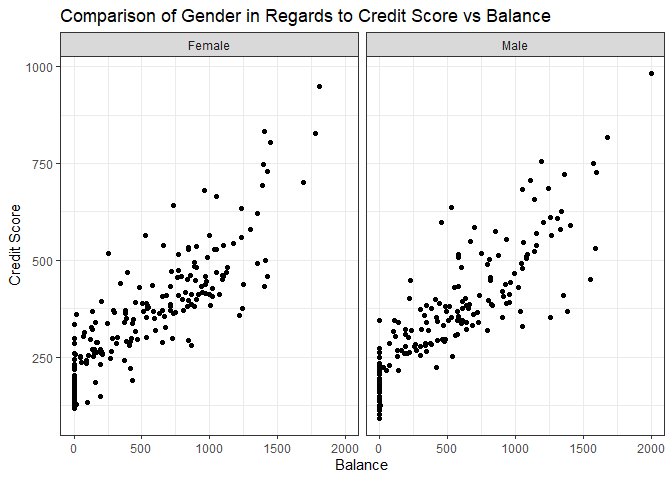

```r
# Create a scatter plot of credit score vs balance
ggplot(credit, aes(x = Balance, y = Rating)) +
  geom_point() +
  # Create two of these scatter plots comparing gender
  facet_wrap(~ Gender) +
  # Create title and axis labels for the graph
  labs(x = "Balance", y = "Credit Score", title = "Comparison of Gender in Regards to Credit Score vs Balance") +
  theme_bw()
```

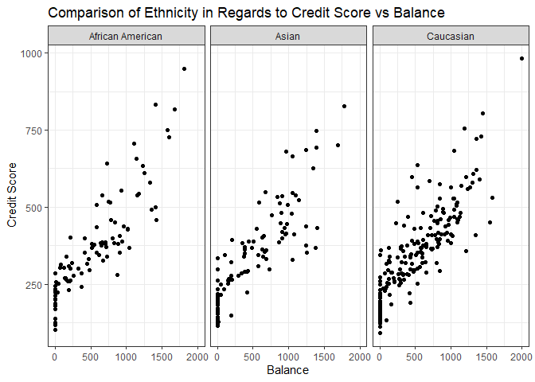

```r
# Create a scatter plot of credit score vs balance
ggplot(credit, aes(x = Balance, y = Rating)) +
  geom_point() +
  # Create two of these scatter plots comparing ethnicity
  facet_wrap(~ Ethnicity) +
  # Create title and axis labels for the graph
  labs(x = "Balance", y = "Credit Score", title = "Comparison of Ethnicity in Regards to Credit Score vs Balance") +
  theme_bw()
```

# Conclusions

The overall story that these graphs depict is that there are trends in regards to credit score, balance, and limit, but not in respect to gender or ethnicity. The objective of the first two analysis was to confirm some simple somewhat obvious trends. One is that people on average tend to have a small number number of credit cards and that having a larger income means qualifying for a higher credit limit on their card. The third analysis shows a major trend that both having a larger limit as well as larger balance tends to result in a higher credit card on average. This could be further explored if we collected data on how much people payed off their credit card each month in regards to their credit score. Lastly a collection of scatter plots of credit score vs balance were compared by the variable gender and then ethnicity. This was to show that surprisingly no sliver of trend was really shown for either even though some people might have guessed/assumed their could be some variation between them.